# Análisis de Comportamiento de Consumo de Combustible con R

## Ajuste y verificación del residual del ARIMA N. Grado 2

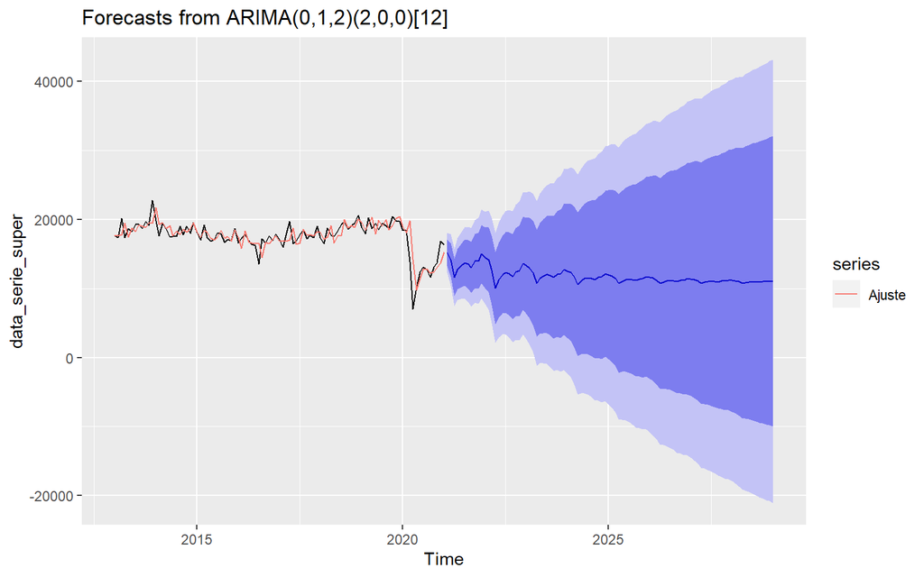

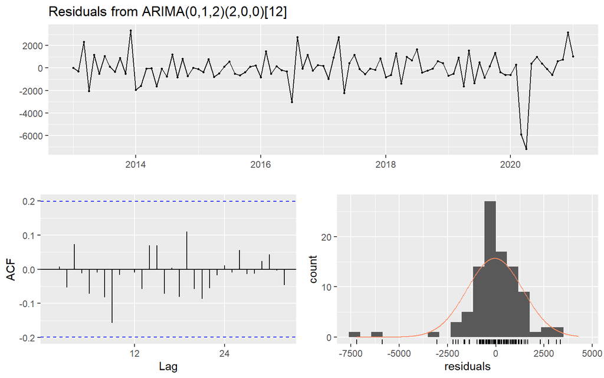

```
    Ljung-Box test

data:  Residuals from ARIMA(0,1,2)(2,0,0)[12]
Q* = 9.3161, df = 15, p-value = 0.8604

Model df: 4.   Total lags used: 19
```

## Ajuste y verificación del residual del Métodos Naive GNC

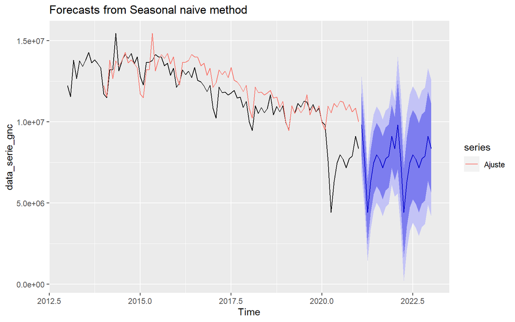

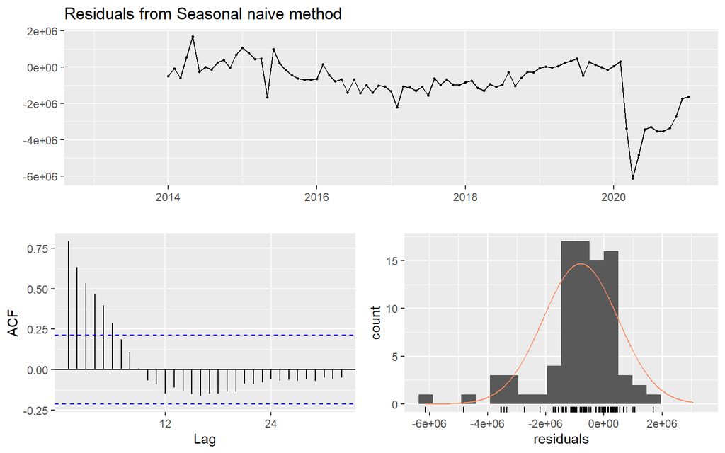

```
    Ljung-Box test

data:  Residuals from Seasonal naive method
Q* = 181.98, df = 19, p-value < 2.2e-16

Model df: 0.   Total lags used: 19
```

## Ajuste y verificación del residual del Método regresión GNC

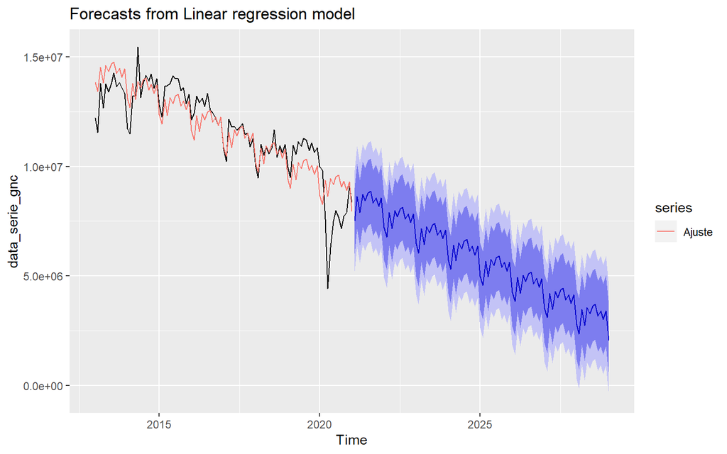

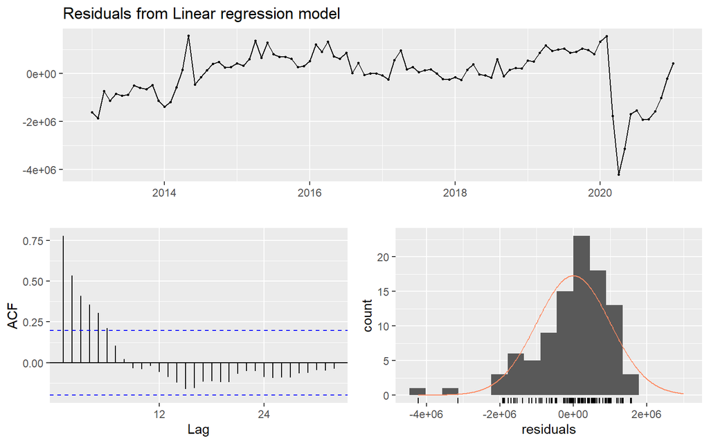

```
    Ljung-Box test

data:  Residuals from Linear regression model
Q* = 149.43, df = 6, p-value < 2.2e-16

Model df: 13.   Total lags used: 19
```

## Ajuste y verificación del residual del Método Holt-Winters GNC

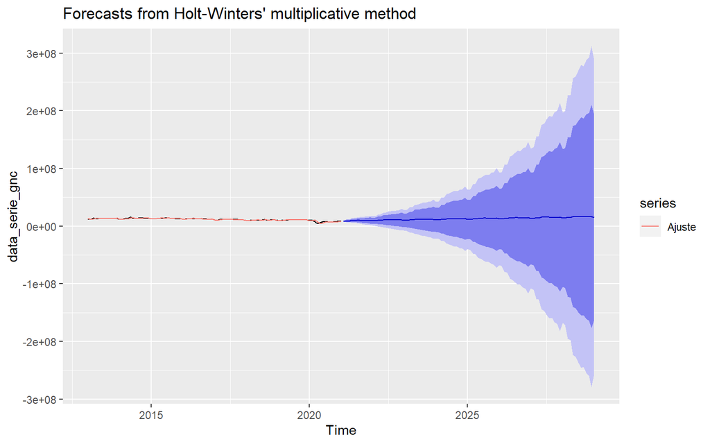

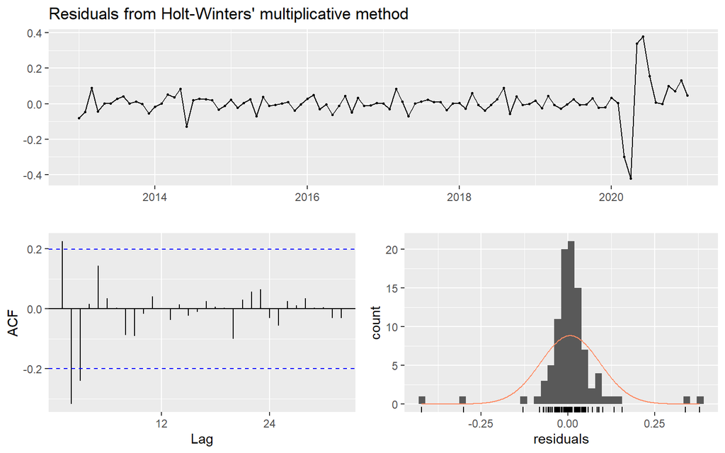

```
    Ljung-Box test

data:  Residuals from Holt-Winters' multiplicative method
Q* = 25.837, df = 3, p-value = 1.032e-05

Model df: 16.   Total lags used: 19
```

## Ajuste y verificación del residual del ARIMA GNC

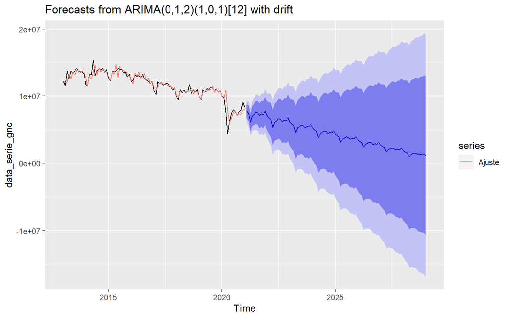

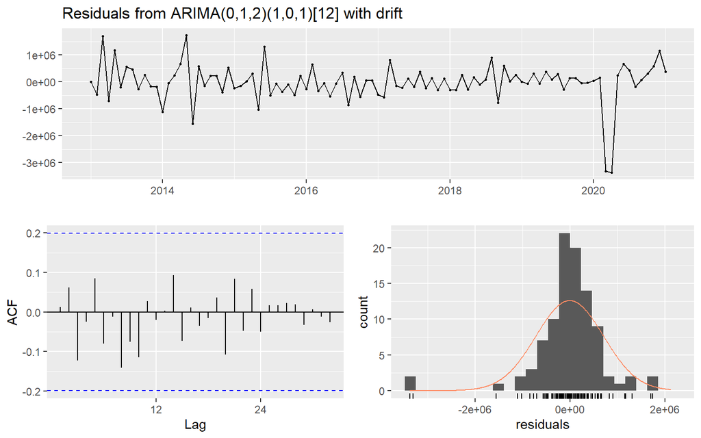

```
    Ljung-Box test

data:  Residuals from ARIMA(0,1,2)(1,0,1)[12] with drift
Q* = 9.7541, df = 14, p-value = 0.7799

Model df: 5.   Total lags used: 19
```

## Ajuste y verificación del residual del Método Naive N. Grado 3

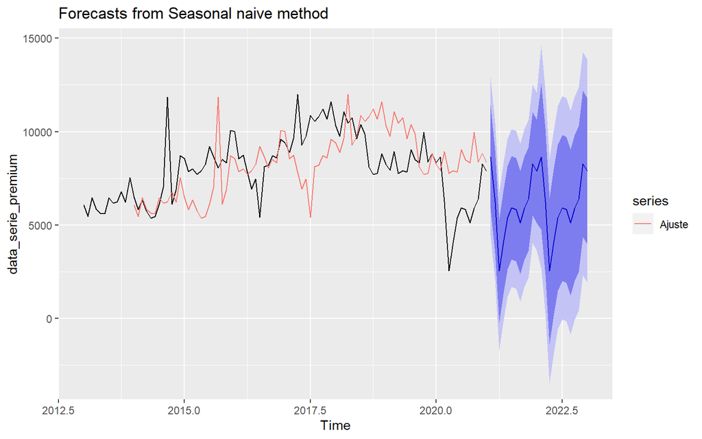

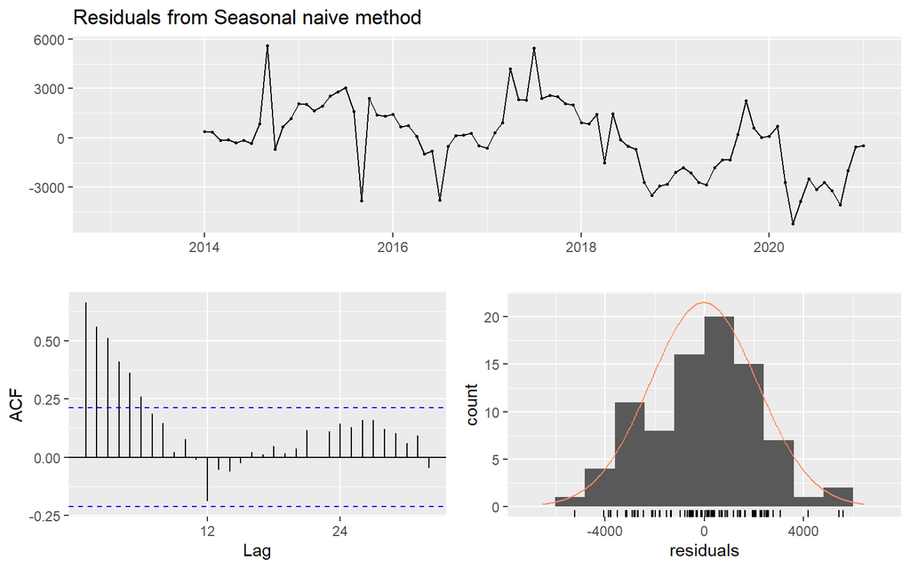

```
    Ljung-Box test

data:  Residuals from Seasonal naive method
Q* = 134.78, df = 19, p-value < 2.2e-16

Model df: 0.   Total lags used: 19
```

## Ajuste y verificación del residual del Método regresión N. Grado 3

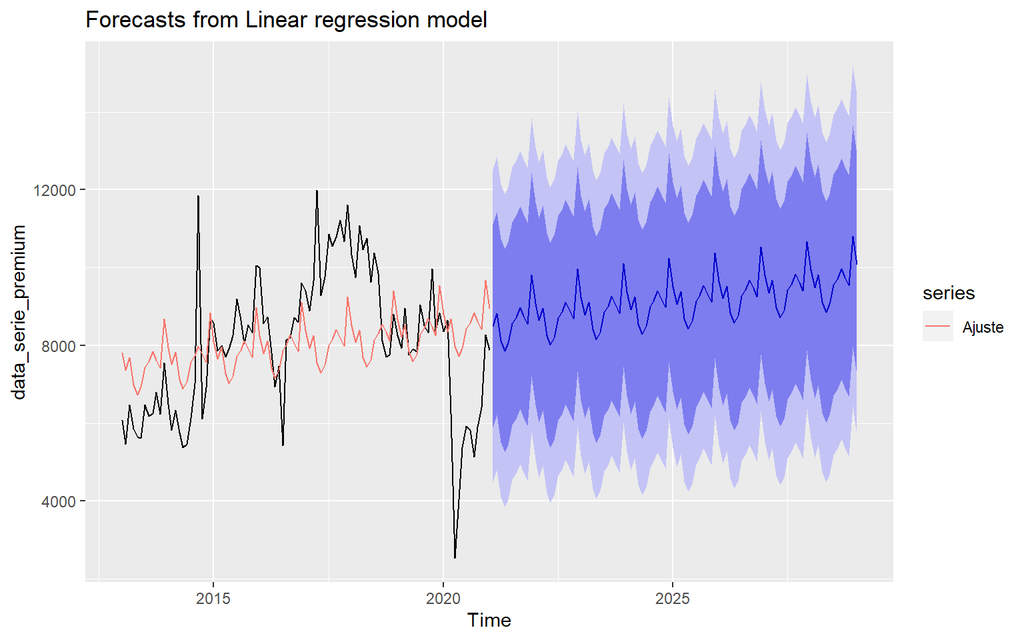

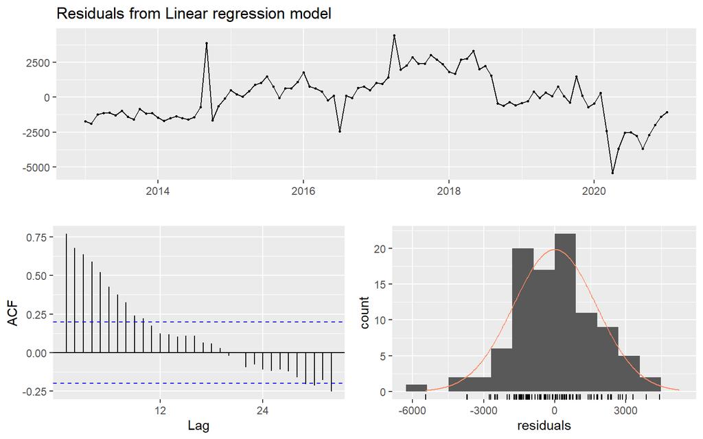

```
    Ljung-Box test

data:  Residuals from Linear regression model
Q* = 281.42, df = 6, p-value < 2.2e-16

Model df: 13.   Total lags used: 19
```

## Ajuste y verificación del residual del Método Holt-Winters N. Grado 3

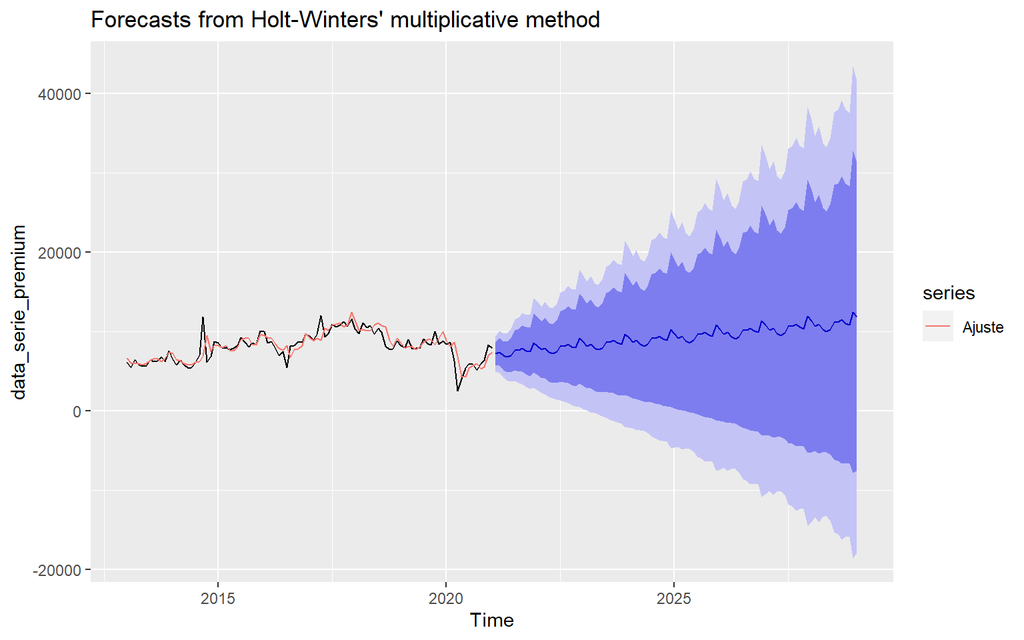

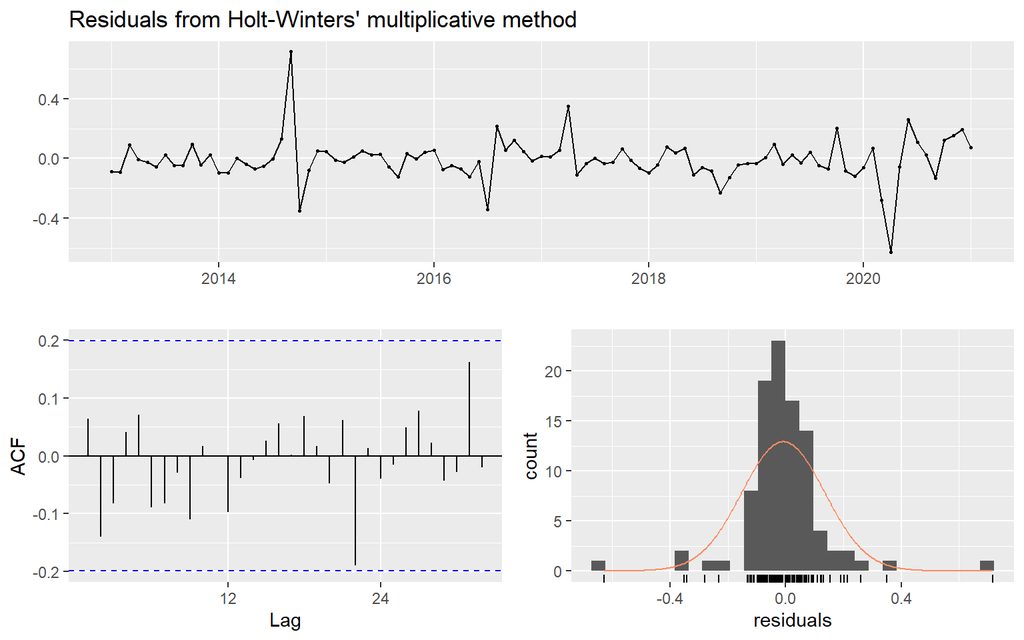

```
    Ljung-Box test

data:  Residuals from Holt-Winters' multiplicative method
Q* = 9.0529, df = 3, p-value = 0.0286

Model df: 16.   Total lags used: 19
```

## Ajuste y verificación del residual del ARIMA N. Grado 3

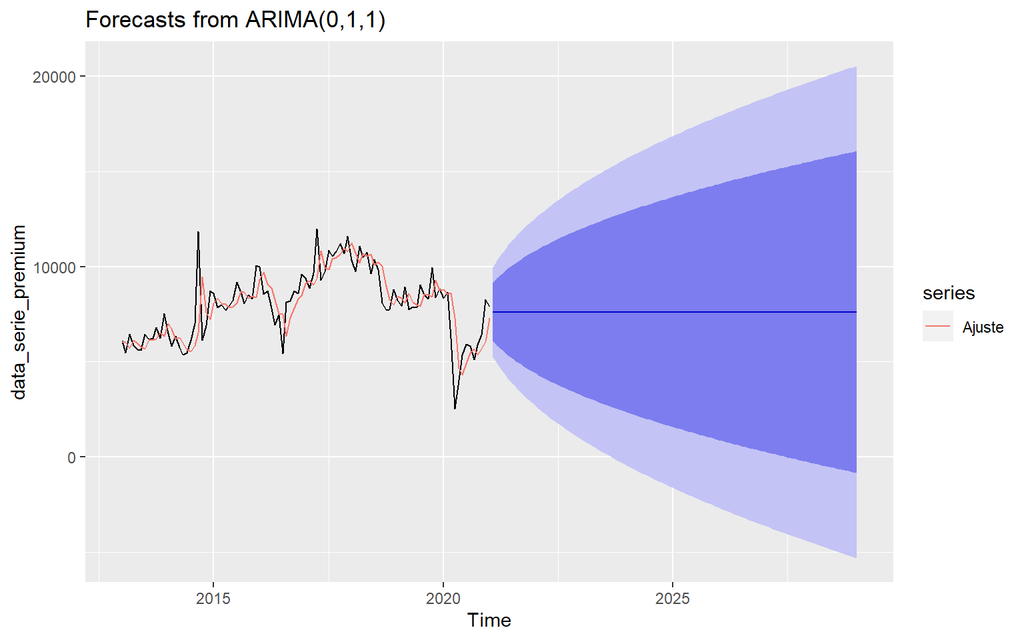

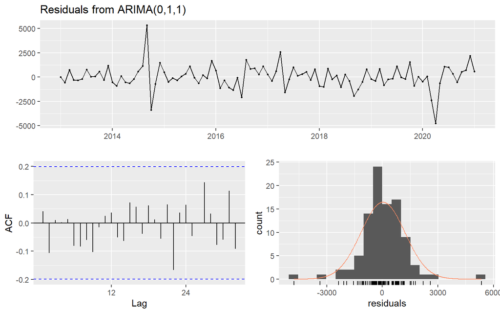

```
    Ljung-Box test

data:  Residuals from ARIMA(0,1,1)
Q* = 7.0294, df = 18, p-value = 0.9899

Model df: 1.   Total lags used: 19
```

## En resumen

El método que tenga los residuales mas cercanos a una distribución normal y que su ajuste esté dentro de los parámetros punteados, mejor es.

La prueba final para evaluar estos métodos se realiza con los datos Reales que sucedan en el futuro y se comparan con los estmados por el pronóstico, esto se realiza evaluando diferentes variables dentro de las cuales la más importante es RMSE (también se calculan MSE y MAPE). El que nos de la menor medida de RMSE es el método predictivo que más se acercará a futuro a los datos reales para ese periodo de tiempo y dentro de una distribución normal. En R esta comparación entre los datos reales y el pronóstico se puede hacer con la función “accuracy(vector datos,..)”,Lo que nos devolverá las variables antes mencionadas dentro de las cuales, el método que menor valor de RMSE tenga, mejor es.